# Ejercicio ANCOVA

Considere el archivo *Ejercicio_ANCOVA*.

1. Realice un analisis descriptivo.
2. Ajuste un modelo ANCOVA.
3. De una intepretación a los resultados.
4. Vea si se puede reducir el modelo, en caso de que se pueda reducir verifique los supuestos.

Todo lo anterior deberá ser realizado en *PYTHON*.

CONTENIDO

- Implementación
  - Datos
  - Análisis exploratorio
- ANCOVA
  - Modelo de RLM
  - Ajuste del modelo
  - Reducción del modelo
  - Modelo reducido
- Verificación de supuestos
  - Linealidad
  - Normalidad
  - Homocedasticidad

## Implementación

### Datos

El interés recae en comparar cuatro aplicaciones. Por simplicidad, se denotan las cuatro aplicaciones con A, B, C y D. Se cuenta con 400 datos.

**Variables**

- $y_i := \text{ Medida de de la aplicación en el individuo } i$
- $x_{i,1} := \text{ Variable de interés 1 para el individuo } i$
- $x_{i,2} := \text{ Variable de interés 2 para el individuo } i$
- $x_{i,j} =\begin{cases} 1, & \text{ si al individuo } i \text{ se le aplicó } j, j=\left \{ A,B,C,D \right \} \\ 0 & \text{ e.o.c } . \end{cases}$

### Análisis exploratorio

Procedamos a ver que sucede con los datos.

| X | y count | y mean | y std | y min | y 25% | y 50% | y 75% | y max |
| --- | --- | --- | --- | --- | --- | --- | --- | --- |
| A | 100.0 | 14.757940 | 3.295384 | 9.006294 | 12.392372 | 14.584917 | 16.582950 | 23.549324 |
| B | 100.0 | 15.132687 | 3.273415 | 7.345269 | 12.781925 | 14.379810 | 17.016111 | 26.558752 |
| C | 100.0 | 15.167974 | 3.542746 | 9.168442 | 13.001388 | 14.265555 | 16.410518 | 28.454093 |
| D | 100.0 | 14.512962 | 3.134622 | 8.049080 | 12.612096 | 13.712806 | 15.626918 | 26.505221 |

| X | y |
| --- | --- |
| A | 10.859553 |
| B | 10.715248 |
| C | 12.551048 |
| D | 9.825853 |

Muestralmente observamos lo siguiente:

- El número de observaciones es el mismo $(n = 100)$ para cada aplicación.
- En promedio la medida para la aplicación $A$ es de 14.76; la de la aplicación $B$ es de 15.13; la de la aplicación $C$ es de 15.17; por último, la de la aplicación $D$ es de 14.51.
- Notamos mayor variabilidad para la aplicación $C$ y menor variabilidad en los datos de $D$.

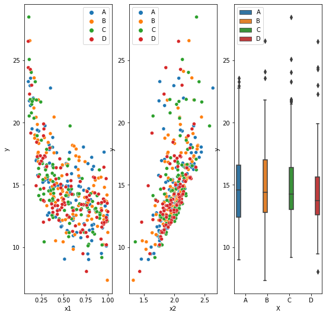

Las gráficas anteriores sugieren que ambas variables influyen en la efectividad de cada aplicación (se nota una pendiente $\neq$ 0 en cada uno de los grupos, para cada variable).

## ANCOVA

### Modelo de RLM

El modelo de *RLM* con interacciones esta parametrizado de la siguiente manera

$y_i = \beta_0 + \underbrace{\beta_1 x_{i,1}}_{Variable 1} + \underbrace{\beta_2 x_{i,2}}_{Variable 2} + \underbrace{\beta_3 x_{i,B} + \beta_4 x_{i,C} + \beta_5 x_{i,D}}_{Tratamiento} + \underbrace{\beta_6 x_{i,B}x_{i,1} + \beta_7 x_{i,C}x_{i,1} + \beta_8 x_{i,D}x_{i,1}}_{\text{Tratamiento con variable 1}} + \underbrace{\beta_9 x_{i,B}x_{i,2} + \beta_{10} x_{i,C}x_{i,2} + \beta_{11} x_{i,D}x_{i,2}}_{\text{Tratamiento con variable 2}} + \epsilon_i$

donde $\epsilon_i \text{N}\left ( 0, \sigma^2 \right ), \forall i\in \left \{ 1 , \dots , n \right \}. $

Observación: En la parametrización del modelo se consideró la aplicación $A$ como el nivel de referencia, entonces

- Si al individuo $i$ se aplica $A$, entonces $x_{i,B}=x_{i,C}=x_{i,D}=0$

$$ \hat{\mathbb{E}}\left [ y_i; X A , x_i \right ] = \hat{ \beta}_0 + \hat{\beta}_1x_{i,1} + \hat{\beta}_2x_{i,2} $$

- Si al individuo $i$ se aplica $B$, entonces $x_{i,B}=1$ y $x_{i,C}=x_{i,D} = 0$

$$ \hat{\mathbb{E}}\left [ y_i; XB , x_i \right ] = \left ( \hat{ \beta}_0 + \hat{\beta}_3 \right ) + \left ( \hat{ \beta}_1 + \hat{\beta}_6 \right )x_{i,1} + \left ( \hat{ \beta}_2 + \hat{\beta}_9 \right )x_{i,2} $$

- Si al individuo $i$ se aplica $C$, entonces $x_{i,C}=1$ y $x_{i,B}=x_{i,D} = 0$

$$ \hat{\mathbb{E}}\left [ y_i; XC , x_i \right ] = \left ( \hat{ \beta}_0 + \hat{\beta}_4 \right ) + \left ( \hat{ \beta}_1 + \hat{\beta}_7 \right )x_{i,1} + \left ( \hat{ \beta}_2 + \hat{\beta}_{10} \right )x_{i,2} $$

- Si al individuo $i$ se aplica $D$, entonces $x_{i,D}=1$ y $x_{i,B}=x_{i,C} = 0$

$$ \hat{\mathbb{E}}\left [ y_i; XD , x_i \right ] = \left ( \hat{ \beta}_0 + \hat{\beta}_5 \right ) + \left ( \hat{ \beta}_1 + \hat{\beta}_8 \right )x_{i,1} + \left ( \hat{ \beta}_2 + \hat{\beta}_{11} \right )x_{i,2} $$

### Ajuste del modelo

```
                            OLS Regression Results
==============================================================================
Dep. Variable:                      y   R-squared:                       0.792
Model:                            OLS   Adj. R-squared:                  0.786
Method:                 Least Squares   F-statistic:                     134.6
Date:                Thu, 22 Sep 2022   Prob (F-statistic):          5.16e-125
Time:                        18:49:18   Log-Likelihood:                -731.90
No. Observations:                 400   AIC:                             1488.
Df Residuals:                     388   BIC:                             1536.
Df Model:                          11
Covariance Type:            nonrobust
==============================================================================
                 coef    std err          t      P>|t|      [0.025      0.975]
------------------------------------------------------------------------------
Intercept      1.4071      1.411      0.997      0.319      -1.367       4.181
x1            -9.2064      0.646    -14.256      0.000     -10.476      -7.937
x2             9.2322      0.690     13.376      0.000       7.875      10.589
XB            -2.2781      2.074     -1.098      0.273      -6.357       1.801
XC            -2.6974      2.175     -1.240      0.216      -6.973       1.578
XD            -1.1818      2.165     -0.546      0.585      -5.438       3.074
x1:XB          1.3776      0.871      1.582      0.114      -0.334       3.090
x1:XC         -0.7230      0.891     -0.812      0.418      -2.475       1.029
x1:XD          0.7434      0.868      0.857      0.392      -0.963       2.449
x2:XB          1.0333      1.007      1.026      0.305      -0.946       3.013
x2:XC          1.2857      1.058      1.215      0.225      -0.794       3.366
x2:XD          0.4477      1.088      0.412      0.681      -1.691       2.586
==============================================================================
Omnibus:                      168.326   Durbin-Watson:                   2.030
Prob(Omnibus):                  0.000   Jarque-Bera (JB):              614.446
Skew:                           1.916   Prob(JB):                    3.76e-134
Kurtosis:                       7.710   Cond. No.                         116.
==============================================================================

Notes:
[1] Standard Errors assume that the covariance matrix of the errors is correctly specified.
```

De acuerdo a los valores obtenidos al ajustar el modelo, se considera la siguiente parametrización: $$\begin{align*} \mathbb{E}\left [ y_i | X, x_{i,1} = x_1^*, x_{i,2} = x_2^* \right ] &= \begin{cases} 1.41 - 9.21 x_1^* + 9.23 x_2^* & \text{ si al individuo } i \text{ se le aplica } A, \\ (1.41 - 2.28) + (- 9.21+1.38) x_1^* + (9.23+1.03) x_2^* & \text{ si al individuo } i \text{ se le aplica } B, \\ (1.41 - 2.70) + (- 9.21-0.72) x_1^* + (9.23+1.29) x_2^* & \text{ si al individuo } i \text{ se le aplica } C,\\ (1.41 - 1.18) + (- 9.21+0.74) x_1^* + (9.23+0.45) x_2^* & \text{ si al individuo } i \text{ se le aplica } D \end{cases}\\ &= \begin{cases} 1.41 - 9.21 x_1^* + 9.23 x_2^* & \text{ si al individuo } i \text{ se le aplica } A, \\ -0.87 -7.83 x_1^* + 10.26 x_2^* & \text{ si al individuo } i \text{ se le aplica } B, \\ -1.29 -9.93 x_1^* + 10.52 x_2^* & \text{ si al individuo } i \text{ se le aplica } C\\ 0.23 -8.47 x_1^* + 9.68 x_2^* & \text{ si al individuo } i \text{ se le aplica } D \end{cases} \end{align*}$$ Se observa que le parámetro asociado a la variable $x_1^*$ es siempre negativo; mientras que el parámetro asociado a la variable $x_2^*$ es siempre positivo. Dependiendo de la condición a medir, de acuerdo al contexto de las aplicaciones, se tendría un comportamiento opuesto entre estos parámetros.

### Reducción del modelo

Para poder reducir el modelo, es necesario verificar

1. ¿El modelo tiene sentido? (interpretar la prueba asociada a la tabla ANOVA). Se plantea la prueba de hipótesis:

$H_0: \beta_1 = \beta_2 = \cdots = \beta_{11} = 0 \text{ v.s. } H_a = \beta_i \neq 0, \text{ para alguna } i = 1, \dots , 11 $

Tiene sentido pues el *p-value* de la prueba asociada a la tabla ANOVA es de: 5.156134400841888e-125

Por lo tanto, rechazamos la hipotesis nula. Concluimos que: Con una confianza del 95% las variables de interés (x1, x2) o alguna de las aplicaciones (A, B, C,D) nos ayudan a modelar el valor promedio de la condicición.

1. ¿El efecto de las variables de interés (*x1*, *x2*) es el mismo en las 4 aplicaciones? (rectas con la misma pendiente). Se plantea la prueba de hipótesis:

$H_0: \beta_j= 0\text{ para toda } j \in\{6,\dots,11\}\text{ v.s. } H_a: \beta_j \neq 0 \text{ para algún } j \in\{6,\dots,11\}$.

Matricialmente (prueba lineal general):

$$H_0: \begin{pmatrix} 0&0&0&0&0&0&1&0&0&0&0&0\\ 0&0&0&0&0&0&0&1&0&0&0&0\\ 0&0&0&0&0&0&0&0&1&0&0&0\\ 0&0&0&0&0&0&0&0&0&1&0&0\\ 0&0&0&0&0&0&0&0&0&0&1&0\\ 0&0&0&0&0&0&0&0&0&0&0&1 \end{pmatrix}\begin{pmatrix} \beta_0 \\ \beta_1 \\ \beta_2 \\ \beta_3 \\ \beta_4\\ \beta_5 \\ \beta_6 \\ \beta_7 \\ \beta_8 \\ \beta_9 \\ \beta_{10} \\ \beta_{11} \end{pmatrix} = \begin{pmatrix} 0\\ 0\\ 0\\ 0\\ 0\\ 0 \end{pmatrix} \text{ v.s. } H_a:\begin{pmatrix} \beta_6 \\ \beta_7 \\ \beta_8 \\ \beta_9 \\ \beta_{10} \\ \beta_{11} \end{pmatrix} \neq \begin{pmatrix} 0\\ 0\\ 0\\ 0\\ 0\\ 0 \end{pmatrix}$$

Para esté apartado lo pasaremos a su lenguaje matricial con lo que obtenemos un *p-value* de: p=0.1986

Por lo tanto no encontramos evidencia estadística suficiente para rechazar la hipótesis nula y concluimos que con una confianza del 95%

1. $\beta_j =0 \text{ para cada } j\in\{6,\dots,11\}$
2. El efecto de las variables de interés no es distinto en promedio para cada aplicación.
3. Todas las pendientes en las interacciones son similares en promedio.

### Modelo reducido

```
                            OLS Regression Results
==============================================================================
Dep. Variable:                      y   R-squared:                       0.788
Model:                            OLS   Adj. R-squared:                  0.785
Method:                 Least Squares   F-statistic:                     292.4
Date:                Thu, 22 Sep 2022   Prob (F-statistic):          3.65e-130
Time:                        18:49:18   Log-Likelihood:                -736.29
No. Observations:                 400   AIC:                             1485.
Df Residuals:                     394   BIC:                             1509.
Df Model:                           5
Covariance Type:            nonrobust
==============================================================================
                 coef    std err          t      P>|t|      [0.025      0.975]
------------------------------------------------------------------------------
Intercept     -0.0973      0.783     -0.124      0.901      -1.637       1.442
x1            -8.8220      0.302    -29.202      0.000      -9.416      -8.228
x2             9.8799      0.380     25.985      0.000       9.132      10.627
XB             0.5692      0.217      2.618      0.009       0.142       0.997
XC            -0.4442      0.218     -2.034      0.043      -0.874      -0.015
XD             0.1321      0.218      0.607      0.544      -0.296       0.560
==============================================================================
Omnibus:                      172.424   Durbin-Watson:                   1.982
Prob(Omnibus):                  0.000   Jarque-Bera (JB):              648.336
Skew:                           1.955   Prob(JB):                    1.64e-141
Kurtosis:                       7.858   Cond. No.                         26.5
==============================================================================

Notes:
[1] Standard Errors assume that the covariance matrix of the errors is correctly specified.
```

## Verificación de supuestos

### Linealidad

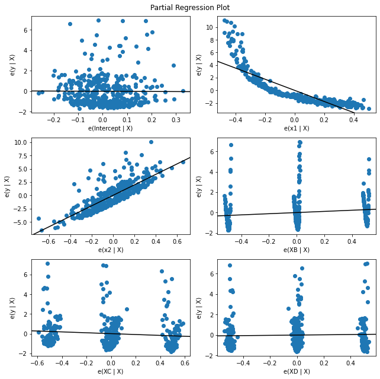

### Normalidad

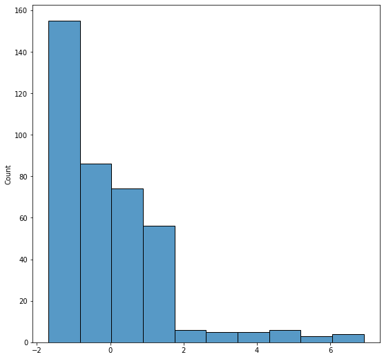

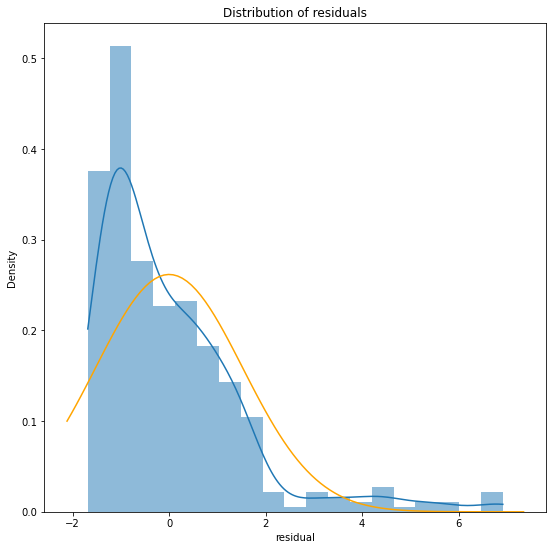

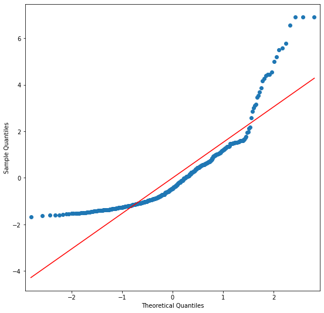

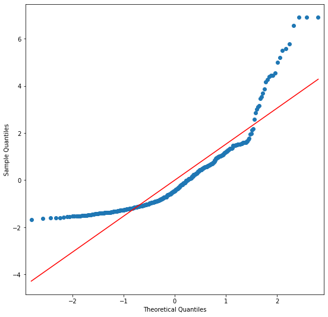

Los test Shapiro-Wilk test y D'Agostino's K-squared test son dos de los test de hipótesis más empleados para analizar la normalidad. En ambos, se considera como hipótesis nula que los datos proceden de una distribución normal.

El p-value de estos test indica la probabilidad de obtener unos datos como los observados si realmente procediesen de una población con una distribución normal con la misma media y desviación que estos. Por lo tanto, si el p-value es menor que un determinado valor (típicamente 0.05), entonces se considera que hay evidencias suficientes para rechazar la normalidad.

```
Prueba de Shapiro-Wilk: Estadístico = 0.8112004995346069, p-value = 2.7095571219558445e-21
```

```
Prueba de D'Agostino: Estadístico = 172.4237801934205, p-value = 3.619527299502789e-38
```

**Por lo tanto, los residuales no tienen distribución normal**

### Homocedasticidad

La suposición de homoscedasticidad es una suposición vital. Si esta suposición es violada, entonces los errores estándar serán sesgados. Los errores estándar se utilizan para realizar pruebas de significación y calcular los intervalos de confianza.

Esto puede ser probado usando un residual vs. valores ajustados, mirando un gráfico de dispersión (si una forma de como está presente entonces heteroscedasticidad está presente), o mediante el uso de una prueba estadística como Bruesch-Pagan, prueba de Cook-Weisberg, o prueba general blanca. En este ejemplo, se utilizará la prueba Bruesch-Pagan, la cuál tienen como hipótesis nula que hay presencia de homocedasticidad.

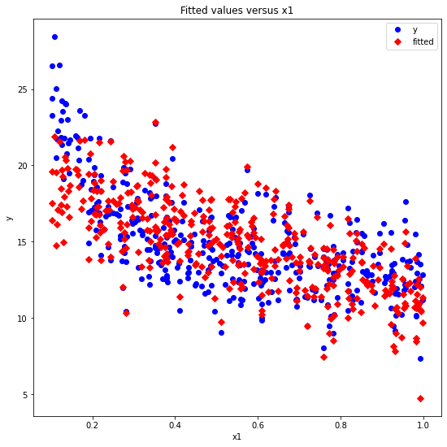

```
Resultados de la prueba de Breusch-Pagan:
  Multiplicador de Lagrange: 60.751254306648626
  p-value: 6.721949152189845e-09
  f-value: 6.316493286526283
  f p-value: 1.2568100976964622e-09
```

**Por lo tanto, los residuales no se distribuyen con varianza similar**